# ReportA3

Shreysa Sharma

10/5/2017

#### Specifications of AWS execution Environment

## m3-xlarge Specifications

| Attribute | Value |
| --- | --- |
| Hadoop Distribution | Amazon 2.7.3 |
| Release Label | emr-5.8.0 |
| Availbility Zone | us east 1-e |
| Instance Type | m3.xlarge |
| vCPU | 4 |
| Memory (GiB) | 15 |
| Storage (GiB) | 2 * 40 SSD |
| Networking Performance | High Intel Xeon E5-2670 v2* |
| Physical Processor Clock Speed (GHz) | 2.5 |
| Intel AVX | Yes |
| Intel AVX2 | Yes |
| Intel Turbo | Yes |
| EBS OPT Enhanced Networking | Yes |

### Summary of the design of evaluated program

The current implementation involves chaining of 2 map reduce jobs. The first map job emits the letter occurances while the reduce job calculates the total letter occurances and then computes the scores as per the requirements given in assignment A0. It then dumps this data into an intermediate file. Since there can be multiple reducers we can have multiple intermediate files, these intermediate files are then merged to provide input to the second map job called the KNeighborhoodMapper. Depending upon the K value passed, “K Ghost words”" are added to the beginning and end of each record sent to mapper, then the mapper starts processIng the file at the k’th word and stops k words before the end of the record. This overlap between records allows for correct kneighbor score calculation. In this approach only 1 record worth of memory is occupied per mapper, The second map job then reads and calculates the word scores of the input files and caches in a hashmap while the second reduce job called the KNeighborhoodReducer calculates the KNeighborhood Median. I did the following changes to my code to support calculation of Median.

private float computeMedian(Iterable values){ List neighborhoodScores = new ArrayList();

```
        for (FloatWritable val: values) {
            neighborhoodScores.add(val.get());
        }
        Collections.sort(neighborhoodScores);

        int size = neighborhoodScores.size();
        int medianIndex = 0;

        if(size % 2 != 0)medianIndex =  (size + 1)/2 - 1;
        else  medianIndex = size/2;
        return neighborhoodScores.get(medianIndex);
    }
```

public void reduce(Text key, Iterable values, Context context) throws IOException, InterruptedException {

```
        float finalScore = computeMedian(values);
        result.set(finalScore);
        context.write(key, result);
    }
```

The current code has another method to compute Mean as well. By just changing call from computeMedian to computeMean will generate the mean instead.

#### Analysis

##### Table 1: Map reduce iterations for K=2 for A2 dataset on 2 nodes and 4 nodes

```r
library(ggplot2)
Map_reduce_run<-read.csv("observations/aws_emr_data.csv")
knitr::kable(Map_reduce_run)
```

| Number_of_Nodes | Time_Taken_big_corpus_in_mins | avg_time_taken_small_corpus_in_mins |
| --- | --- | --- |
| 2 | 158 | 11 |
| 4 | 145 | 8 |

The above table represents the total time taken for the big corpus when run on 2 and 4 nodes, it also presents the data for total average time of 3 runs of map reduce job on small corpus in minutes. The 2 node run took 158 minutes and 4 node run took 145 minutes for the big corpus and 11 minutes on 2 nodes and 8 minutes on 4 nodes for the small corpus.

##### Plot 1: Total Time Taken in minutes vs Num of nodes

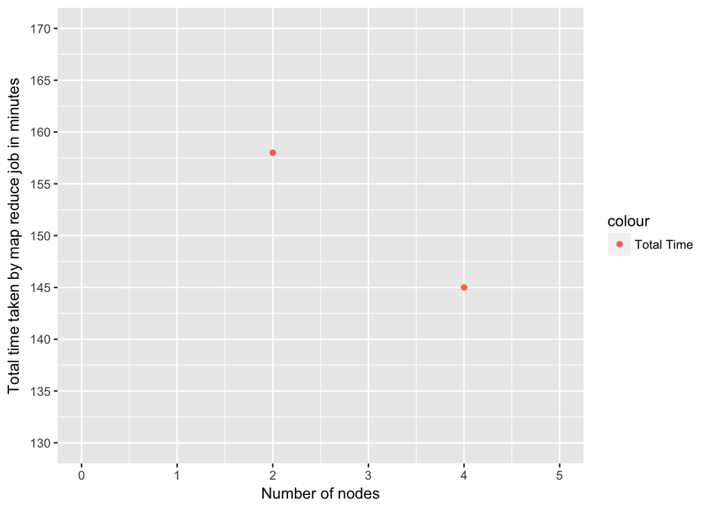

```r
ggplot(Map_reduce_run, aes(x=Number_of_Nodes, y=Time_Taken_big_corpus_in_mins, color="Total Time")) +
  geom_point() +
  ylab("Total time taken by map reduce job in minutes") +
  xlab("Number of nodes") +
  scale_y_continuous(breaks=seq(130,170,5),  limits = c(130,170))+
  scale_x_continuous(breaks=seq(0,5,1), limits = c(0,5))
```

```r
Map_reduce_run_local<-read.csv("observations/Map_reduce_run_local.csv")
knitr::kable(Map_reduce_run)
```

[output not shown]

##### Plot 2: Total Time Taken in minutes vs Num of runs

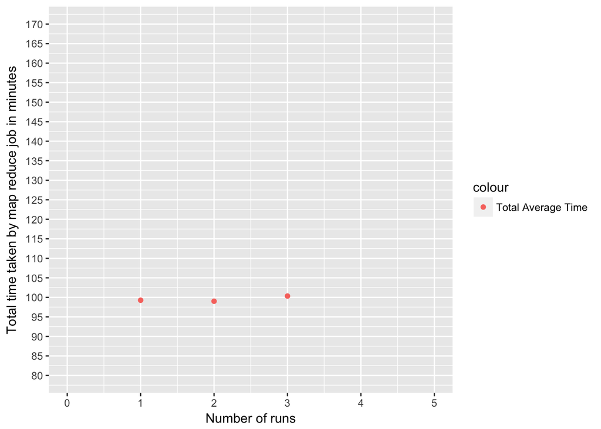

```r
ggplot(Map_reduce_run_local, aes(x=Runs, y=total_time_taken, color="Total Average Time")) +
  geom_point() +
  ylab("Total time taken by map reduce job in minutes") +
  xlab("Number of runs") +
  scale_y_continuous(breaks=seq(80,170,5),  limits = c(80,170))+
  scale_x_continuous(breaks=seq(0,5,1), limits = c(0,5))
```

The jobs were run on AWS EMR clusters and it was noted that the actual run time on EMR was greater than the one recieved on hadoop. There was marginal difference between the 4 node and 2 node run time. Also, a few changes were needed to be done in the set up method of the reducers in order to to be able to handle multiple reducers .